# Mulches: Role in Climate Resilient Agriculture - ScienceDirect

[figure not shown]

## Figures (5)

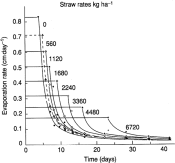

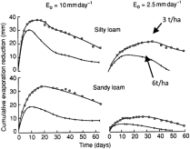

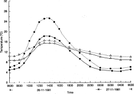

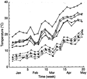

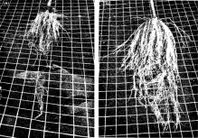

## [Reference Module in Earth Systems and Environmental Sciences](https://www.sciencedirect.com/science/referenceworks/9780124095489)

2018

# Mulches: Role in Climate Resilient Agriculture☆

[C.L.Acharya<sup>1</sup>](https://www.sciencedirect.com/science/article/pii/B9780124095489116549#!)[K.K.Bandyopadhyay](https://www.sciencedirect.com/science/article/pii/B9780124095489116549#!)[K.M.Hati](https://www.sciencedirect.com/science/article/pii/B9780124095489116549#!)

https://doi.org/10.1016/B978-0-12-409548-9.11654-9[Get rights and content](https://s100.copyright.com/AppDispatchServlet?publisherName=ELS&contentID=B9780124095489116549&orderBeanReset=true)

## Abstract

Mulches, organic or inorganic in nature, favorably moderate soil's hydrothermal regime, assume significance in the context of climate change. The in-situ mulching under conservation agriculture avoids [crop residue](https://www.sciencedirect.com/topics/earth-and-planetary-sciences/crop-residue) burning. Besides improving crop growth, moderation of [soil moisture regime](https://www.sciencedirect.com/topics/earth-and-planetary-sciences/soil-moisture-regime), buffering soil temperature fluctuations, facilitating soil aeration, [seedling emergence](https://www.sciencedirect.com/topics/earth-and-planetary-sciences/seedling-emergence), improving root growth, efficient water and nutrient use by crop plants it also improves the environment by facilitating [carbon sequestration](https://www.sciencedirect.com/topics/earth-and-planetary-sciences/carbon-sequestration) and reducing [greenhouse gas emissions](https://www.sciencedirect.com/topics/earth-and-planetary-sciences/greenhouse-gas-emission) from the soil. Appropriate policy decisions to overcome limitations in adoption of conservation agriculture and mulching are required by providing technical and financial support to the farmers.

## Keywords

Carbon sequestration

Conservation agriculture

Crop residue burning

Crop residue mulch

GHG emissions

Input use efficiency

Mulches

Plastic mulches

Root growth

Soil moisture

Soil temperature

## Cited by (0)

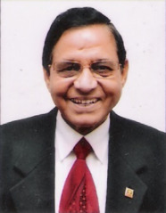

**C.L. Acharya** was born on 06 April 1945. He did his B.Sc. (Agri.) in 1966 from Punjab Agricultural University (PAU), Ludhiana; M.Sc. (Soil Sci.) in 1968 from Hisar campus of PAU and Ph.D. in 1971 with Gold Medal from Indian Agricultural Research Institute (IARI), New Delhi. He was a postdoctoral fellow in IMG, Grenoble, France and INRA, Versailles, France from 1975 to 1977. He served ICAR (Indian Council of Agricultural)- CSSRI (Central Soil Salinity Research Institute), Karnal as Soil Physicist, 1972–79; associate professor, 1979–87; chief scientist (WM), 1987–93; chief scientist & head department of soil science, and director extension education, 2003–05, Himachal Pradesh (HP) Agricultural University, Palampur and a director of ICAR- Indian Institute of Soil Science, Bhopal from 1998 to 2003.

He is the recipient of several National Awards including 12th International Congress Commemoration Award of the Indian Society of Soil Science (ISSS), 1989; Hooker Award of IARI, 1993; ICAR- Hari Om Ashram Trust Award (1999) and Dr. N. S. Randhawa Memorial Award of the National Academy of Agricultural Sciences (NAAS) for his scientific contributions. He has guided 11 M.Sc. & Ph.D. students for their thesis work; published 160 research papers, bulletins, books, scientific reviews and popular articles. He is the fellow of the ISSS (1993); Fellow of the National Academy of Agricultural Sciences (NAAS, 1998); Fellow, National Academy of Sciences (FNASc), India (2003) and Fellow Indian Society of Water Management (2007).

He was a Member of Expert Working Group on Himalayan Eco- Development Research Programme of Government of India (1988–90); Member Science Advisory Committee, GB Pant Institute of Himalayan Environment & Development (1990–93); Member Task Force, DST (2000–02); Member Academic Council Jawahar Lal Nehru Agricultural University, Jabalpur (2001–03); HP Agricultural University, Palampur (2004–05); Member & Chairman of several Research Advisory Committees of ICAR's Research Institutes and Member of several ICAR's Institutes Quinquinnial Review Teams; Convener, 6th Agricultural Science Congress, NAAS (2003). Member GB Pant Society for Himalayan Environment & Development (2007–10); Member Executive Council, NAAS, 2008–2010; Consultant (Soil Expert), Cambodia, April- May & August- September, 2010; Member ICAR- Farmers First Committee (2011–12); Member Empowered Committee of National Agricultural Science Fund of ICAR (2015–18); Expert Member ICAR-National Innovations for Climate Resilient Agriculture (2017–till date).

He had been a Member on the Editorial Board of the Journal of the ISSS (1992–95, 2001–03); Soil & Tillage Research (1997–2015) and is currently on the Editorial Board of NAAS Journal Agricultural Research (2015– till date).

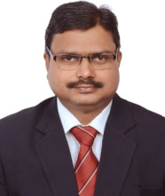

**K.K. Bandyopadhyay** was born in Bhubaneswar, Odisha, India on 1 March 1969. He did his B.Sc. (Ag) in 1990 and M.Sc. (Ag) in 1993 from Orissa University of Agriculture and Technology, Bhubaneswar and Ph.D. in 1997 from Indian Agricultural Research Institute New Delhi. He is presently serving as Principal Scientist (Soil Physics and Soil and Water Conservation), Division of Agricultural Physics, ICAR-Indian Agricultural Research Institute, New Delhi 2010 to date. He served as scientist, ICAR-Indian Institute of Soil Science, Bhopal (1999–2005), senior scientist, ICAR-Central Institute for Cotton Research, Regional Station, Coimbatore (2005–2010). He has received following awards viz., Dr. K.G. Tejwani Award of Indian Association of Soil and Water Conservationists for the biennium 2014–15 for Natural Resource Management, 2017; 12th International Soil Science Congress Commemoration Award of the Indian Society of Soil Science, 2015; IMPHOS-FAI Award on “Role of phosphorus on yield and quality of crops”, 2005; Zonal Award for the East Zone of the Indian Society of Soil Science for outstanding Doctoral Research, 1999; Fertilizer Association of India Silver Jubilee Award for Outstanding Doctoral Research in Fertilizer Usage, 1998; IARI merit medal for outstanding academic performance in doctor of philosophy degree program, 1999. Fellow, National Academy of Agricultural Sciences, 2016.

His research areas includes water and nitrogen dynamics in soil-plant system and improving input use efficiency, carbon sequestration and soil physical health under different conservation agriculture practices, crop simulation modelling. Published 120 research papers in refereed journals of National and International repute, 11 book chapters and 7 manuals.

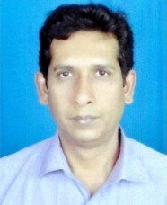

**K.M. Hati** was born on 28 May 1969. He did his B.Sc. (Ag) in 1991 from Bidhan Chandra Krishi Viswa Vidyalaya, Mohanpur, West Begal and M.Sc. (Ag) in 1993 and Ph.D. in 1996 from Indian Agricultural Research Institute, New Delhi. He has received following awards viz., Golden Jubilee Commemoration Young Scientist Award of Indian Society of Soil Science, Associate Fellowship of National Academy of Agricultural Sciences, ISSS- Dr. J.S.P. Yadav Memorial Award for Excellence in Soil Science of Indian Society of Soil Science as a team member, Doreen Mashler Award 2006 of ICRISAT (CGIAR) as a team member of the IISS-ICRISAT Collaborative Project on Watershed Management, Recipient of Endeavour Research Fellowship 2018 for postdoctoral research by Government of Australia. His research areas includes Soil Science – Soil Physics, Soil quality and health, Conservation agriculture, Hyper-spectral remote sensing and precision farming, Soil water conservation and recycling. He has published 72 research papers in refereed journals of National and International repute, book chapters and manuals. He is presently serving as Principal Scientist, Division of Soil Physics, ICAR-Indian Institute of Soil Science, Bhopal, India.

**<sup>☆</sup>**

*Change History*: October 2018. Acharya, C.L., Hati, K.M. and Bandyopadhyay, K.K. updated the text and added new references and one photo “Plate 1.”

**<sup>☆☆</sup>**

This article is an update of the previous article: Acharya, C.L., Hati, K.M. and Bandyopadhyay, K.K. (2005) Mulches. In (Hillel, D., Rosenzweig, C., Powlson, D.S., Scow, K.M., Singer, M.J., Sparks, D.L. and Hatfield, J. eds.) *Encyclopedia of Soils in the Environment*, pp. 521–532. Elsevier Publication.

**<sup>1</sup>**

Ex-Director, 28 Nagarkot Colony, Thakurdwara, PO Maranda, Palampur 176102 (HP), India.

Copyright © 2018 Elsevier Inc. All rights reserved.

[figure not shown]

[figure not shown]